# NLME results output

Charlotte Woolley

*Overall Summary of Data After Error and Duplication Simulation (and before cleaning)*

Total induced errors = 2508

Total induced duplications = 30310

Total induced complete duplications = 29892

Mean = 63.6137728

Median = 35.38

SD = 1135.6975017

Range = 0.00221, 120630

Number of observations = 255188

Number of individuals = 42803

*Graph of data before NLME method*

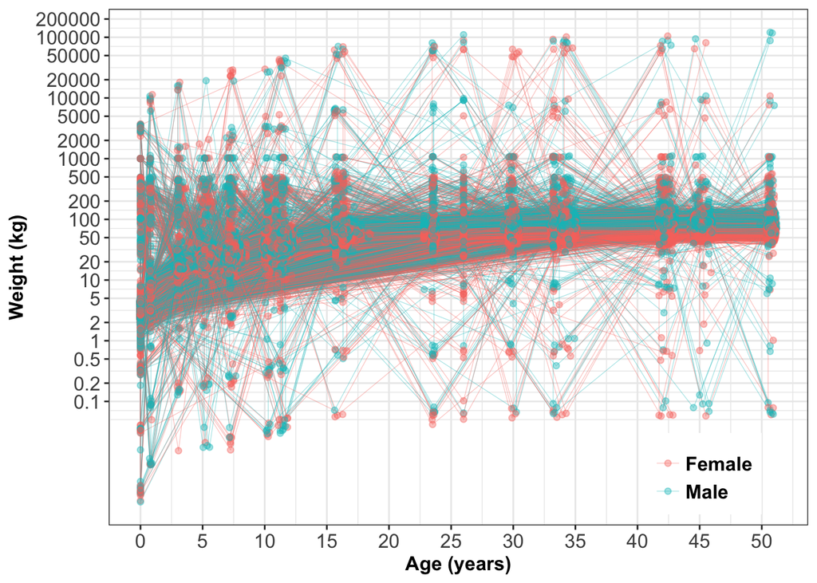

*Overall Summary of NLME Method Performance (after data cleaning)*

Mean = 40.9399227

Median = 34.93

SD = 30.1640821

Range = 0.00221, 190.48

Number of observations = 234120

Number of individuals = 42800

Sensitivity = 87.0813397

Specificity = 99.7910401

Total deletions = 21068

Percentage deleted = 8.2558741

Complete duplications deletions (or step 1 of algorithm) = 18356

Non-complete (identical) duplications deletions (or step 2 of algorithm) = 303

Total modifications (or step 3 of algorithm) = 0

Add 100 modifications = 0

Add 1000 modifications = 0

Subtract 100 modifications = 0

Subtract 1000 modifications = 0

Multiply by 10 modifications = 0

Multiply by 100 modifications = 0

Multiply by 1000 modifications = 0

Divide by 10 modifications = 0

Divide by 100 modifications = 0

Divide by 1000 modifications = 0

Convert to kg modifications = 0

Convert to lbs modifications = 0

Transpose modifications = 0

Jumping measurements deletions (or step 4 of algorithm) = 0

*Graph of data after NLME method*

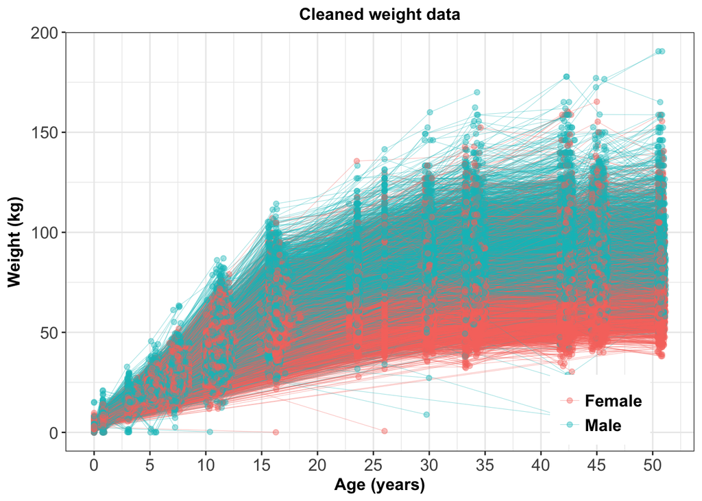